# Project 3 - Ensemble techniques

#### Importing libraries

```python
import numpy as np
import pandas as pd
import matplotlib.pyplot as plt
import seaborn as sns
%matplotlib inline
from sklearn.metrics import accuracy_score, f1_score, recall_score, precision_score, roc_auc_score, confusion_matrix, precision_recall_curve, roc_curve
from sklearn.model_selection import train_test_split
from sklearn.tree import DecisionTreeClassifier
from sklearn.ensemble import RandomForestClassifier
from sklearn.ensemble import BaggingClassifier
from sklearn.ensemble import AdaBoostClassifier
#from sklearn.preprocessing import LabelEncoder
#labelencoder=LabelEncoder()

import warnings
warnings.filterwarnings('ignore')
```

#### Loading data into dataframe

```python
bank_data=pd.read_csv('bank-full.csv')
```

```python
bank_data.head(10)
```

|  | age | job | marital | education | default | balance | housing | loan | contact | day | month | duration | campaign | pdays | previous | poutcome | Target |
| --- | --- | --- | --- | --- | --- | --- | --- | --- | --- | --- | --- | --- | --- | --- | --- | --- | --- |
| 0 | 58 | management | married | tertiary | no | 2143 | yes | no | unknown | 5 | may | 261 | 1 | -1 | 0 | unknown | no |
| 1 | 44 | technician | single | secondary | no | 29 | yes | no | unknown | 5 | may | 151 | 1 | -1 | 0 | unknown | no |
| 2 | 33 | entrepreneur | married | secondary | no | 2 | yes | yes | unknown | 5 | may | 76 | 1 | -1 | 0 | unknown | no |
| 3 | 47 | blue-collar | married | unknown | no | 1506 | yes | no | unknown | 5 | may | 92 | 1 | -1 | 0 | unknown | no |
| 4 | 33 | unknown | single | unknown | no | 1 | no | no | unknown | 5 | may | 198 | 1 | -1 | 0 | unknown | no |
| 5 | 35 | management | married | tertiary | no | 231 | yes | no | unknown | 5 | may | 139 | 1 | -1 | 0 | unknown | no |
| 6 | 28 | management | single | tertiary | no | 447 | yes | yes | unknown | 5 | may | 217 | 1 | -1 | 0 | unknown | no |
| 7 | 42 | entrepreneur | divorced | tertiary | yes | 2 | yes | no | unknown | 5 | may | 380 | 1 | -1 | 0 | unknown | no |
| 8 | 58 | retired | married | primary | no | 121 | yes | no | unknown | 5 | may | 50 | 1 | -1 | 0 | unknown | no |
| 9 | 43 | technician | single | secondary | no | 593 | yes | no | unknown | 5 | may | 55 | 1 | -1 | 0 | unknown | no |

```python
bank_data.shape
```

```
(45211, 17)
```

There are more then 45k cases and 17 variables (including target varibale as well). Some of the varibales are multiclass categorical variable (e.g. job - management, technician, entrepeneur, etc...), some are categorical with only two categories (like default or housing, etc.). There is also "unknown" class recognized in varibales like contact, education or poutcome.

## Deliverable 1 - Exploratory data analysis

### 1.1 Univariate analysis

#### 1.1.1 Data types and description of the independent attributes which should include name, range of values observed, central values (mean and median), standard deviation and quartiles, skewness

```python
bank_data.info()
```

```
<class 'pandas.core.frame.DataFrame'>
RangeIndex: 45211 entries, 0 to 45210
Data columns (total 17 columns):
 #   Column     Non-Null Count  Dtype
---  ------     --------------  -----
 0   age        45211 non-null  int64
 1   job        45211 non-null  object
 2   marital    45211 non-null  object
 3   education  45211 non-null  object
 4   default    45211 non-null  object
 5   balance    45211 non-null  int64
 6   housing    45211 non-null  object
 7   loan       45211 non-null  object
 8   contact    45211 non-null  object
 9   day        45211 non-null  int64
 10  month      45211 non-null  object
 11  duration   45211 non-null  int64
 12  campaign   45211 non-null  int64
 13  pdays      45211 non-null  int64
 14  previous   45211 non-null  int64
 15  poutcome   45211 non-null  object
 16  Target     45211 non-null  object
dtypes: int64(7), object(10)
memory usage: 5.9+ MB
```

Some of the variables are of numerical type 64 bit integer like age, balance, day, duration, campaign, pdays, previous. The rest are objects which should be converted to categorical variables.

```python
#changing dtype from object to category
for i in bank_data.columns:
    if bank_data[i].dtype=='object':
        bank_data[i]=pd.Categorical(bank_data[i])
```

```python
bank_data.dtypes
```

```
age             int64
job          category
marital      category
education    category
default      category
balance         int64
housing      category
loan         category
contact      category
day             int64
month        category
duration        int64
campaign        int64
pdays           int64
previous        int64
poutcome     category
Target       category
dtype: object
```

```python
bank_data.describe(include='all').T
```

|  | count | unique | top | freq | mean | std | min | 25% | 50% | 75% | max |
| --- | --- | --- | --- | --- | --- | --- | --- | --- | --- | --- | --- |
| age | 45211 | NaN | NaN | NaN | 40.9362 | 10.6188 | 18 | 33 | 39 | 48 | 95 |
| job | 45211 | 12 | blue-collar | 9732 | NaN | NaN | NaN | NaN | NaN | NaN | NaN |
| marital | 45211 | 3 | married | 27214 | NaN | NaN | NaN | NaN | NaN | NaN | NaN |
| education | 45211 | 4 | secondary | 23202 | NaN | NaN | NaN | NaN | NaN | NaN | NaN |
| default | 45211 | 2 | no | 44396 | NaN | NaN | NaN | NaN | NaN | NaN | NaN |
| balance | 45211 | NaN | NaN | NaN | 1362.27 | 3044.77 | -8019 | 72 | 448 | 1428 | 102127 |
| housing | 45211 | 2 | yes | 25130 | NaN | NaN | NaN | NaN | NaN | NaN | NaN |
| loan | 45211 | 2 | no | 37967 | NaN | NaN | NaN | NaN | NaN | NaN | NaN |
| contact | 45211 | 3 | cellular | 29285 | NaN | NaN | NaN | NaN | NaN | NaN | NaN |
| day | 45211 | NaN | NaN | NaN | 15.8064 | 8.32248 | 1 | 8 | 16 | 21 | 31 |
| month | 45211 | 12 | may | 13766 | NaN | NaN | NaN | NaN | NaN | NaN | NaN |
| duration | 45211 | NaN | NaN | NaN | 258.163 | 257.528 | 0 | 103 | 180 | 319 | 4918 |
| campaign | 45211 | NaN | NaN | NaN | 2.76384 | 3.09802 | 1 | 1 | 2 | 3 | 63 |
| pdays | 45211 | NaN | NaN | NaN | 40.1978 | 100.129 | -1 | -1 | -1 | -1 | 871 |
| previous | 45211 | NaN | NaN | NaN | 0.580323 | 2.30344 | 0 | 0 | 0 | 0 | 275 |
| poutcome | 45211 | 4 | unknown | 36959 | NaN | NaN | NaN | NaN | NaN | NaN | NaN |
| Target | 45211 | 2 | no | 39922 | NaN | NaN | NaN | NaN | NaN | NaN | NaN |

There are 45211 non null values in all columns. Number of unique values and mode could be seen for categorical variables in the output above. Spread measures (min, median, max) and central tendency measures (mean, std) can be seen for numerical values. Number of unique categories for "month" are as expected - 12, the same is for "housing", "loan", "default", etc. "Duration" has mean value gretaer then median value and max value much greater compared to standard deviation. It indicates right skewness (leakege of the values to right side). "pdays" has, at least 75% of values equal to -1. It may be considered as unreliable varibale since this umber should always be postivie (number of days). Mode of "poutcome" is "unknown" (more then 80%), so most probably this varibale should be excluded from the dataset before building a model, since it does not provide much of information.

#### 1.1.2 Make a function to plot ‘countplot’ if the variable is categorical and ‘distplot’ if the variable is numeric.

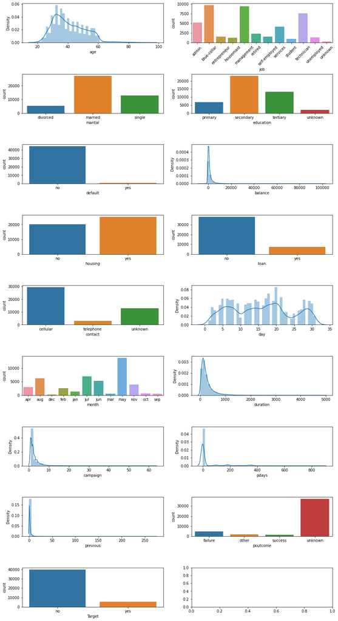

```python
# get_xy() function returns position of subplots.
#It recieves col and row index and return the
#next one based on the two columns layout
def get_xy(x, y):
    if y==1:
        return (x+1, 0)
    else:
        return (x, 1)

#arranging subplots in 2 columns and 9 rows
fig, axs = plt.subplots(nrows=9, ncols=2, figsize=(15,30))

#setting initial values of col and row index
x=0
y=0

for i in bank_data.columns:
    if bank_data[i].dtype.name=='category':#discriminating category from other numerical dtypes
        if i=='job': # because of too long names of categories labels are rotated
            plot=sns.countplot(bank_data[i], ax=axs[x,y])
            plt.setp(plot.get_xticklabels(), rotation=45)
        else:
            sns.countplot(bank_data[i], ax=axs[x,y])
        x, y=get_xy(x, y)#getting a next values for col and row index for next subplot
    else:
        sns.distplot(bank_data[i], ax=axs[x,y])
        x, y=get_xy(x, y)

#adjustemnts of subplots arrangement in space
plt.subplots_adjust(hspace=0.8, wspace=0.2)
plt.show()
```

It can be seen that ages are slightly right skewed, but not too much. Most frequent jobs are blue-collar, management and technician, and for education, most frequent is secondary. Housing is much more balanced compared to loan (taking into account that both are loans - one for housing and the other as personal loan). In fact, loan might be considered as imbalanced data. For the contact, predominant is cellular, but there is fair amount of unknown class repsresented in this varibale as well. Day and month the customer has been contacted are, more or less, evenly distributed throughout the spread of values. May is the month when most of the contacts were made, and dec, mar, oct and sep are the months when least of contacts were made. "Day" of the month is numerical (continuous) varible, however, to be consistent with "month", it may be converted to categorical. Conversion to categorical will lead to too many categories - 31. DUration and campaign show right skewness, while pdays is extremly right skewed whit great majority of values being equal to -1, rendering it as unreliable. Poutcome is highly imbalanced, having unknown class as predominant. In addition to failure and success class, there is also "other" class which does not provide clear information about success of previous marketing campaign. Target varibale is inbalanced, which might have been expected, since the aim of analysis and predictions is to increase success rate.

Based on above analysis "pdays" and "poutcome" should be removed from data set.

#### 1.1.3 Identify outliers using IQR and verify the same using plots. Also mention the percentage of data points which are considered outliers. Should we treat them, why or why not?

```python
Q1=bank_data.quantile(0.25)
Q3=bank_data.quantile(0.75)
IQR=Q3-Q1
```

```python
IQR
```

```
age           15.0
balance     1356.0
day           13.0
duration     216.0
campaign       2.0
pdays          0.0
previous       0.0
dtype: float64
```

Some of IQRs should be disregarded as follows:

- IQR of 'day' vairable has no meaning because of it's context (last contact day of the month);
- IQR for 'pdays' and 'previous' are extremly right skewed and there is no difference betwen Q1 and Q3 and as a result all values other then 0 are outliers; in addition most of the values for pdays are equal to -1 which indicates the value may not be known at the time of record;

```python
#droping some irelevant IQRs
IQR.drop(['day','pdays','previous'], inplace=True)
```

```python
IQR
```

```
age           15.0
balance     1356.0
duration     216.0
campaign       2.0
dtype: float64
```

```python
#generating a dict of variables where the sub-dataframe
#(selected based on outliers of that particular variable) is stored as value
outliers={}
for i in IQR.index:
    outliers["{0}".format(i)]=bank_data[(bank_data[i]>Q3[i]+1.5*IQR[i])|(bank_data[i]<Q1[i]-1.5*IQR[i])]
```

Now, outliers can be easily extracted from dictionary "outliers". This approach allows us to see outliers for each varibale, but also all the other variables associated with a case having an outlier

```python
#number of values of each outlier
#for this particular varibale, number of unique outliers is not to great,
#so value_counts was used in this case
outliers['age']['age'].value_counts()
```

```
71    54
72    52
73    44
77    44
75    39
74    37
76    32
80    31
78    30
79    25
83    22
82    19
81    17
84     9
86     9
85     5
87     4
89     3
88     2
90     2
92     2
93     2
95     2
94     1
Name: age, dtype: int64
```

```python
outliers['balance']['balance']
```

```
34       10635
65        6530
69       12223
70        5935
186       4384
         ...
45164     4655
45181     6879
45185     4256
45191     3810
45208     5715
Name: balance, Length: 4729, dtype: int64
```

```python
outliers['duration']['duration']
```

```
37       1666
43       1492
53        787
59       1778
61        812
         ...
45124     701
45199    1166
45200    1556
45206     977
45208    1127
Name: duration, Length: 3235, dtype: int64
```

```python
outliers['campaign']['campaign']
```

```
758       7
780       8
906       7
1103      8
1105      7
         ..
44666     7
44680     9
44770     9
44886    12
45056     7
Name: campaign, Length: 3064, dtype: int64
```

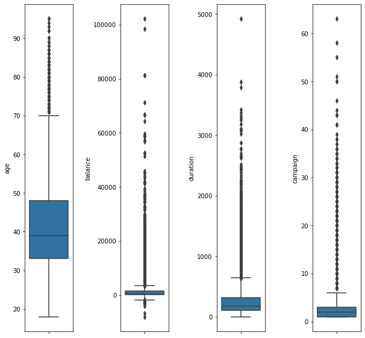

```python
#arranging subplots in 4 columns
fig, axs=plt.subplots(ncols=4, figsize=(10,10))
y=0# a varibale used as col index; setting to 0

#loop through all columns of the original dataset identified in IQR
for i in IQR.index:
    sns.boxplot(y=bank_data[i], ax=axs[y])
    y=y+1

#adjusting a vertical spacing between subplots relative to the size of subplots
plt.subplots_adjust(wspace=1)
plt.show()
```

As expected, outliers lower then Q1-1.5IQR were found only in balance, while the rest were only in the area Q3+1.5IQR.

Outliers are values that falls over 3 standard deviation from the mean value and in normal distribution it would be less than 0.3% of data.

In our case numbers of outliers are as follows:

- for age 487 (1.08%)
- for balance 4729 (10.46%)
- for duration 3235 (7.16%)
- for campaign 3064 (6.78%)

If we follow more conservative approach (Chebyshev rule) - around 88.88% of data should fall within 3 standard deviation from the mean. The results are consistent with such expectations (NOTE: it has to be taken into consideration that different method for identification of outliers have been used for above numbers - IQR was used and not z score which would make such statement fully valid).

The above could be done using the method of equal frequency discretization. "Equal frequency binning divides the possible values of the variable into N bins, where each bin carries the same amount of observations. This is particularly useful for skewed variables as it spreads the observations over the different bins equally. Typically, we find the interval boundaries by determining the quantiles." [1]

[1] https://medium.com/towards-artificial-intelligence/outlier-detection-and-treatment-a-beginners-guide-c44af0699754

```python
balance_discretised, intervals=pd.qcut(bank_data.balance, 7, labels=[1,2,3,4,5,6,7], retbins=True, precision=3, duplicates='raise')
```

pd.qcut function has been used for this purpose, as indicated in a code above. 7 intervals have been generated for balance with labels from 1 to 7. The amount of bins have been selected by try and test, where the idea was to get as evenly distributed data across bins as possible, while keeping the difference between those considered as outliers (bin labeled with 7) separate, as well as those that are below 0 of balance.

Similar approach has been used for the other two variables.

Afterwards, everything was recorded in a new dataframe, while removing the original related columns.

```python
duration_discretised, intervals=pd.qcut(bank_data.duration, 7, labels=[1,2,3,4,5,6,7], retbins=True, precision=3, duplicates='raise')
```

```python
campaign_discretised, intervals=pd.qcut(bank_data.campaign, 2, labels=[1,2], retbins=True, precision=3, duplicates='raise')
```

```python
intervals
```

```
array([ 1.,  2., 63.])
```

```python
bank_data_discretised=bank_data.copy()
bank_data_discretised['balance_d']=balance_discretised
bank_data_discretised['duration_d']=duration_discretised
bank_data_discretised['campaign_d']=duration_discretised
```

```python
bank_data_discretised.drop(labels=['balance','duration', 'campaign'], axis=1, inplace=True)
```

Resulting columns must be converted into numerical dtype so correlation could be checked afterwards.

```python
bank_data_discretised['balance_d']=pd.to_numeric(bank_data_discretised['balance_d'])
bank_data_discretised['duration_d']=pd.to_numeric(bank_data_discretised['duration_d'])
bank_data_discretised['campaign_d']=pd.to_numeric(bank_data_discretised['campaign_d'])
```

#### 1.2.1. Make a function to plot boxplots for all continuous variables VS ‘Target’ variable and countplots for all categorical variables VS ‘Target’ variable?

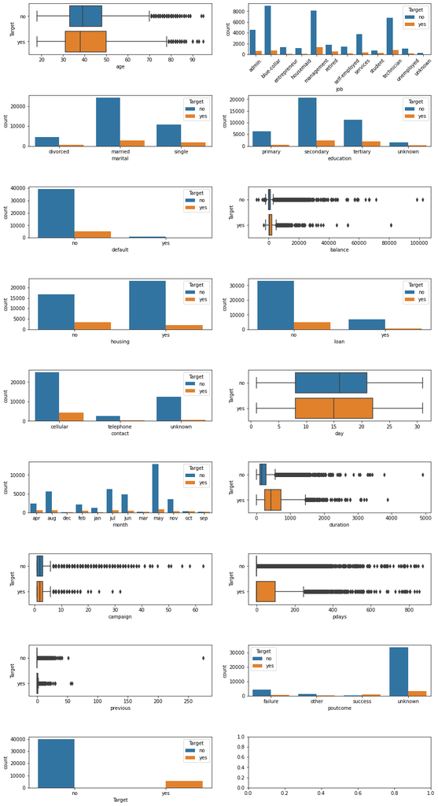

```python
#organizing subplots into 2 columns and 9 rows
fig, axs=plt.subplots(nrows=9, ncols=2, figsize=(15,30))

#setting initial col and row index values
x=0
y=0

#looping through all the columns
for i in bank_data.columns:
    if bank_data[i].dtype.name=='category':
        if i=='job': #see the comments in code for 1.1.2
            plot=sns.countplot(bank_data[i], ax=axs[x,y], hue=bank_data['Target'])
            plt.setp(plot.get_xticklabels(), rotation=45)
        else:
            #hue parameter is used in countplot to group categories based on target variable
            sns.countplot(bank_data[i], ax=axs[x,y], hue=bank_data['Target'])
        x, y=get_xy(x, y)#using a function defined in step 1.1.2
    else:
        #y axis used for target variable to enable consistent size and layout of each subplot
        sns.boxplot(y=bank_data['Target'], x=bank_data[i], ax=axs[x,y])
        x, y=get_xy(x, y)
plt.subplots_adjust(hspace=0.8, wspace=0.2)
plt.show()
```

Based on above graphs, it may be concluded that only "duration" has different distribution for 2 classes of "target variables". "Yes" class of "Target" varibale tend to have longer duration of last contact.

The rest of graphs shows no major differences in distribution of values between those classes (Yes and No class of Target variable).

All values of "previous" variable greater than 0 are outliers because of IQR=0, so no conclusion can be provided on this one. Issues with "pdays" and "poutcome" have already been addressed earlier.

The last graph in this context is meaningless because it shows count of Tagret classes distributed among same clasess of same variable.

#### 1.2.2 Bi-variate analysis between predictor variables and target column. Comment on your findings in terms of their relationship and degree of relation if any. Visualize the analysis using pair plots, heatmaps, histograms or density curves

To enable coorelation analysis with regards to target variable, and since "no" and "yes" classes are not recognized as 0/1 or False/True by python, the convesrion has to be made. While doing it for "Target" variable, it will be done for other variables with same classes (no/yes).

```python
#dictionary which maps certain values with a replacement value
no_yes_replacement_dict={'no': 0, 'yes': 1}
bank_data.replace(to_replace=no_yes_replacement_dict, inplace=True)
bank_data_discretised.replace(to_replace=no_yes_replacement_dict, inplace=True)
```

```python
bank_data.describe(include='all').T
```

|  | count | unique | top | freq | mean | std | min | 25% | 50% | 75% | max |
| --- | --- | --- | --- | --- | --- | --- | --- | --- | --- | --- | --- |
| age | 45211 | NaN | NaN | NaN | 40.9362 | 10.6188 | 18 | 33 | 39 | 48 | 95 |
| job | 45211 | 12 | blue-collar | 9732 | NaN | NaN | NaN | NaN | NaN | NaN | NaN |
| marital | 45211 | 3 | married | 27214 | NaN | NaN | NaN | NaN | NaN | NaN | NaN |
| education | 45211 | 4 | secondary | 23202 | NaN | NaN | NaN | NaN | NaN | NaN | NaN |
| default | 45211 | NaN | NaN | NaN | 0.0180266 | 0.133049 | 0 | 0 | 0 | 0 | 1 |
| balance | 45211 | NaN | NaN | NaN | 1362.27 | 3044.77 | -8019 | 72 | 448 | 1428 | 102127 |
| housing | 45211 | NaN | NaN | NaN | 0.555838 | 0.496878 | 0 | 0 | 1 | 1 | 1 |
| loan | 45211 | NaN | NaN | NaN | 0.160226 | 0.36682 | 0 | 0 | 0 | 0 | 1 |
| contact | 45211 | 3 | cellular | 29285 | NaN | NaN | NaN | NaN | NaN | NaN | NaN |
| day | 45211 | NaN | NaN | NaN | 15.8064 | 8.32248 | 1 | 8 | 16 | 21 | 31 |
| month | 45211 | 12 | may | 13766 | NaN | NaN | NaN | NaN | NaN | NaN | NaN |
| duration | 45211 | NaN | NaN | NaN | 258.163 | 257.528 | 0 | 103 | 180 | 319 | 4918 |
| campaign | 45211 | NaN | NaN | NaN | 2.76384 | 3.09802 | 1 | 1 | 2 | 3 | 63 |
| pdays | 45211 | NaN | NaN | NaN | 40.1978 | 100.129 | -1 | -1 | -1 | -1 | 871 |
| previous | 45211 | NaN | NaN | NaN | 0.580323 | 2.30344 | 0 | 0 | 0 | 0 | 275 |
| poutcome | 45211 | 4 | unknown | 36959 | NaN | NaN | NaN | NaN | NaN | NaN | NaN |
| Target | 45211 | NaN | NaN | NaN | 0.116985 | 0.321406 | 0 | 0 | 0 | 0 | 1 |

Basic statistics output of .describe function shows how it has been changed for Target varibale compared to one done in 1.1.1.

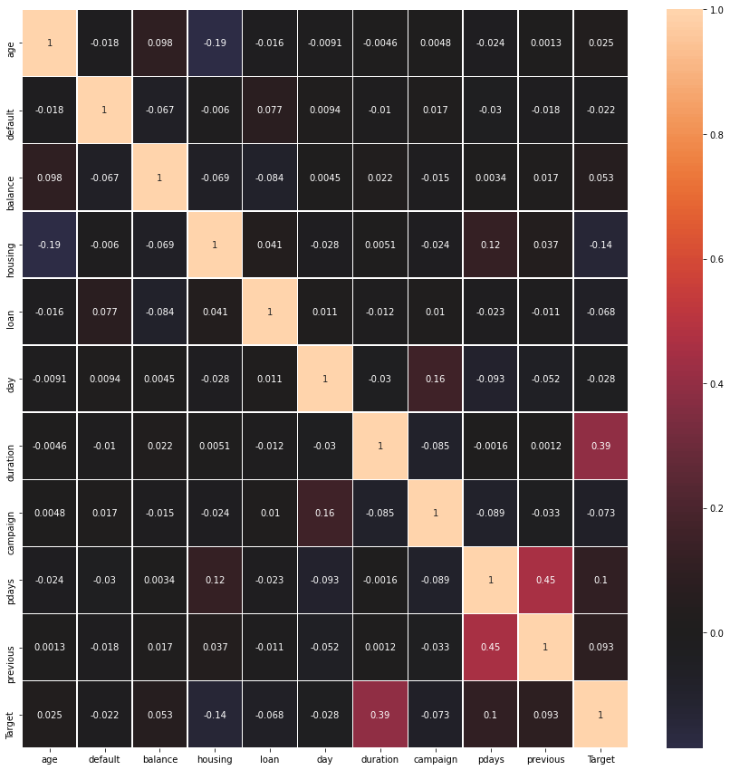

```python
fig, ax=plt.subplots(figsize=(15,15))
plot=sns.heatmap(bank_data.corr(), center=0, annot=True, linewidths=0.5)
```

It is worth noting there are still some categorical variables which could not be included in heatmap since those are consisted of "string" classes (e.g "job", "marital", "education" etc). Heatmap might be plot again after one hot encoding is done, to make sure there are no dependant varibales in dataset used for training of models (in 2.1).

There are no significant correlation between present variables in heatmap. The highes correlation can be seen between "duration" and "target" variables (which has been identified using boxplot in 1.2.1) and between "previous" and "pdays", however, the correlation is still low (0.45 and 0.39).

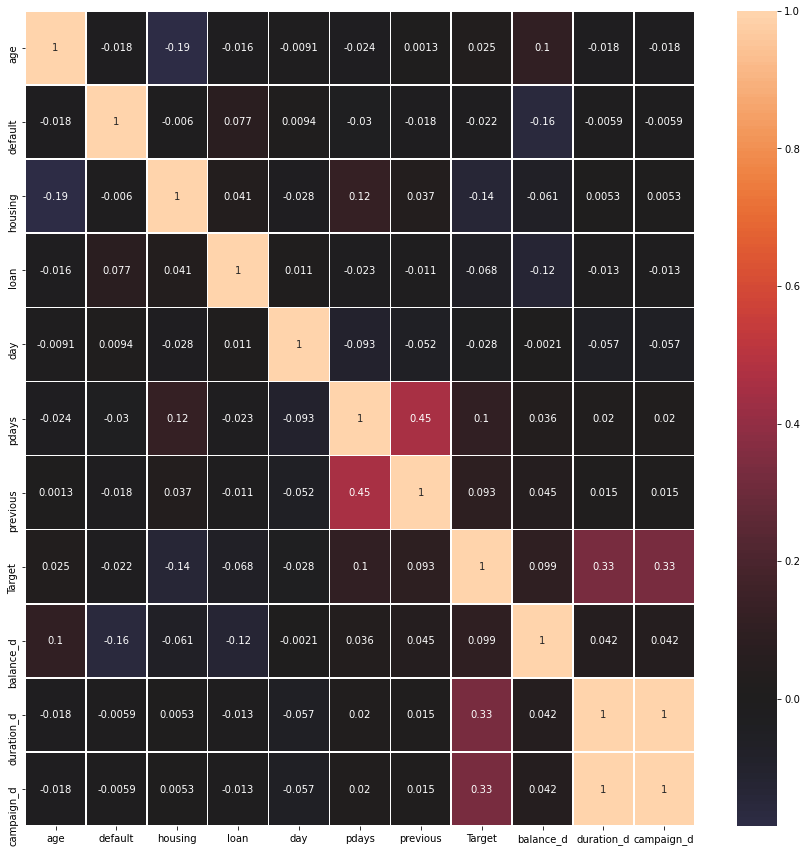

```python
fig, ax=plt.subplots(figsize=(15,15))
plot=sns.heatmap(bank_data_discretised.corr(), center=0, annot=True, linewidths=0.5)
```

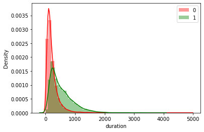

```python
sns.distplot(bank_data[bank_data['Target']==0]['duration'], color='r', label=0, kde=True)
sns.distplot(bank_data[bank_data['Target']==1]['duration'],color='g',label=1)
plt.legend()
plt.show()
```

Distribution plot of duration variable in subsets with regards to target variable shows slight correlation of duration with target class, however it does not look significant. Significant portion of the graphs are overlaped.

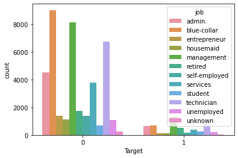

```python
sns.countplot(bank_data['Target'], hue=bank_data['job'])
```

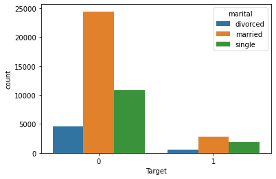

```python
sns.countplot(bank_data['Target'], hue=bank_data['marital'])
```

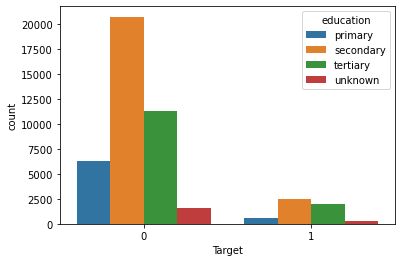

```python
sns.countplot(bank_data['Target'], hue=bank_data['education'])
```

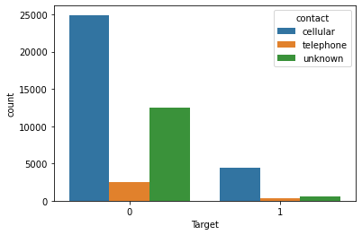

```python
sns.countplot(bank_data['Target'], hue=bank_data['contact'])
```

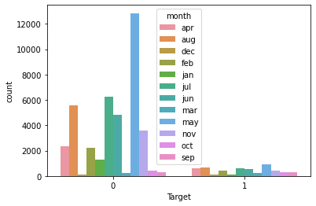

```python
sns.countplot(bank_data['Target'], hue=bank_data['month'])
```

## Deliverable 2 - Prepare data for analytics

### 2.1. Label encode or create dummy variables for categorical variables. Give reason for selecting either of them

```python
bank_data=bank_data.drop(['pdays', 'poutcome'], axis=1)
bank_data_discretised=bank_data_discretised.drop(['pdays', 'poutcome'], axis=1)
```

Variables "pdays" and "poutcome" has been removed from dataset as indicated in insight of 1.1.2

```python
bank_data=pd.get_dummies(data=bank_data, drop_first=True, columns=['job','marital', 'education','contact','month', 'day'])
bank_data_discretised=pd.get_dummies(data=bank_data_discretised, drop_first=True, columns=['job','marital', 'education','contact','month', 'day'])
```

Dummy variables have been created because classes of varibales that needed to be transformed could not be ordered, so label encode would not make any benefit.

"day" variable was also transformed to make it consistent with the rest of dataset

```python
#as identified in correlation heatmap
bank_data_discretised.drop(labels='campaign_d', axis=1, inplace=True)
```

```python
bank_data.shape
```

```
(45211, 68)
```

Heatmap should be plotted just for quick reference if there are some significant correlation between generated varibles which could not be seen before.

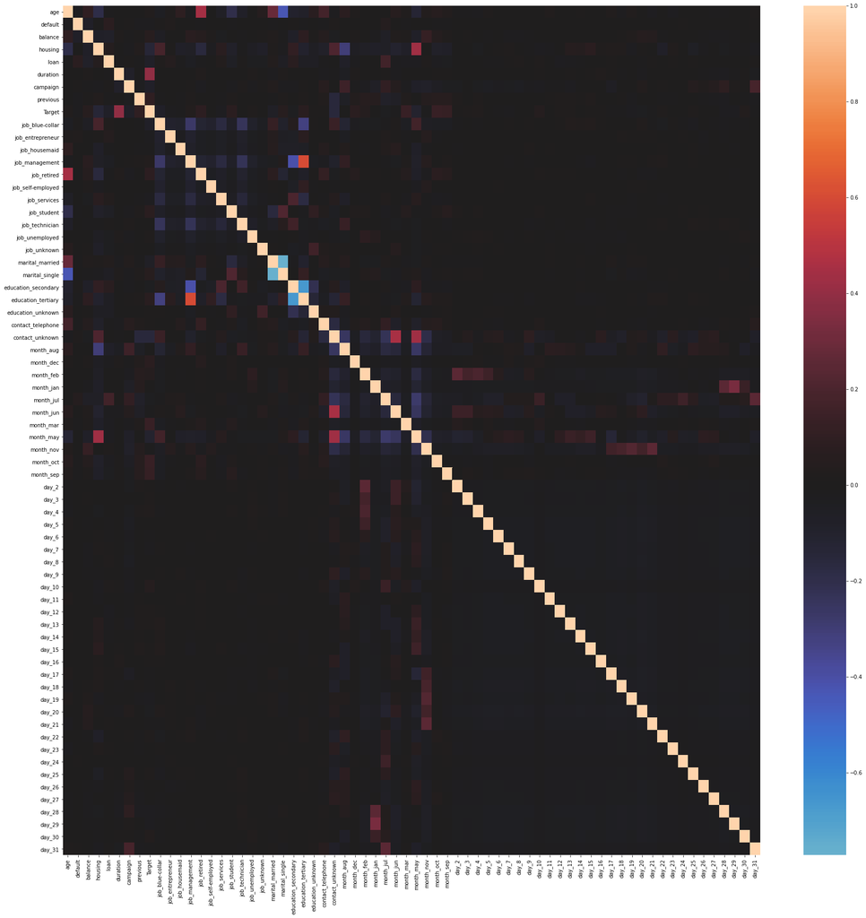

```python
fig, ax=plt.subplots(figsize=(30,30))
plot=sns.heatmap(bank_data.corr(), center=0)
```

```python
bank_data['marital_married'].corr(bank_data['marital_single'])
```

```
-0.7723572028441662
```

```python
bank_data['education_tertiary'].corr(bank_data['education_secondary'])
```

```
-0.6628897452785849
```

```python
bank_data['job_management'].corr(bank_data['education_tertiary'])
```

```
0.5988998438608242
```

```python
bank_data['job_management'].corr(bank_data['education_secondary'])
```

```
-0.4061237920796406
```

Some of the relationships have been checked in details because heatmap indicated higher correlation compared to other relationship.

Correlation between marital_married and marital_single is fairly strong (-0.77), therefore, one should be removed.

Moderate correlation has been identified between other two pairs. Education_tertiary is present in both pairs, so if we eliminate only that variable, we eliminate two pairs of moderate correlation (there is no such moderate correlation between other two counterparts in those two pairs - last correlation).

```python
bank_data=bank_data.drop(['marital_single', 'education_tertiary'], axis=1)

#the assumption was made that the same occurs in other dataframe as well:
bank_data_discretised=bank_data_discretised.drop(['marital_single', 'education_tertiary'], axis=1)
```

```python
bank_data.shape
```

```
(45211, 66)
```

### 2.2. Create the training set and test set in a ratio of 70:30. Make sure and verify distribution of classes is the same in the full dataset and train test split data

```python
X_train, X_test, y_train, y_test=train_test_split(bank_data[bank_data.columns.drop('Target')], bank_data['Target'], test_size=0.3, random_state=7)

X_train_d, X_test_d, y_train_d, y_test_d=train_test_split(bank_data_discretised[bank_data_discretised.columns.drop('Target')], bank_data['Target'], test_size=0.3, random_state=7)
```

2 sets of data are prepared for training:

- the one derived from bank_data
- the other derived from modified version of above - bank_data_discretised.

To verify same distribution among test, train and original sets, the function is made to calculate either percentage of each class for each variable in dataframe, or mean and std if the varibale is not categorical. the result of such function is dataframe providing basic info about distribution of classes/values in given dataframe.

Function "summary_df" (described above) is fed with

- original dataframe and
- resulting dataframes after the split is made.

Comparison of the values has been done on all related dataframes, but also the visual representation has been provided below where distribution of classes of each varibale has been ploted against varibales. Please note, 'Target' variable has been removed from original dataframe while fed to "summary_df", to make the layout of all tree related dataframes comparable (original, train and test dataframes).

The presentation below is only done on bank_data, X_train and X_test, to reduce the size of this document.

Distribution of target varibale can be easily done by applying "summary_df" and providing as an input only bank_data['Target'] and y_train and y_test convertd to dataframe (e.g. pd.DataFrame(y_train, columns=['Target'])).

In a conclusion, no difference in data distribution has been noticed in splitted dataset compared to original ones. The same distribution pattern could be found in bank_data as well as in X_train, y_train, X_test, y_test.

```python
def summary_df(dataframe):
    summary_df=pd.DataFrame()
    for i in dataframe.columns:
        if dataframe[i].nunique()<8:
            #fdgs
            summary_df=pd.concat([summary_df,
                                  pd.DataFrame(100*dataframe[i].value_counts()/dataframe[i].value_counts().sum())],
                                axis=1)
        else:
            dict_mean={}
            dict_mean["{0}".format(i)]=dataframe[i].mean()

            dict_std={}
            dict_std["{0}".format(i)]=dataframe[i].std()

            mean_std_df=pd.concat([pd.DataFrame(dict_mean, index=['mean']),
                                   pd.DataFrame(dict_std, index=['std'])])

            summary_df=pd.concat([summary_df,
                                  mean_std_df],
                                axis=1)

    return summary_df
```

```python
bank_d_sum=summary_df(bank_data.drop(columns='Target'))
bank_d_train_sum=summary_df(X_train)
bank_d_test_sum=summary_df(X_test)
```

```python
bank_d_sum
```

|  | age | default | balance | housing | loan | duration | campaign | previous | job_blue-collar | job_entrepreneur | ... | day_22 | day_23 | day_24 | day_25 | day_26 | day_27 | day_28 | day_29 | day_30 | day_31 |
| --- | --- | --- | --- | --- | --- | --- | --- | --- | --- | --- | --- | --- | --- | --- | --- | --- | --- | --- | --- | --- | --- |
| 0 | NaN | 98.197341 | NaN | 44.416182 | 83.977351 | NaN | NaN | NaN | 78.474265 | 96.710977 | ... | 97.998275 | 97.923072 | 99.011303 | 98.142045 | 97.710734 | 97.520515 | 95.952312 | 96.14032 | 96.536241 | 98.57778 |
| 1 | NaN | 1.802659 | NaN | 55.583818 | 16.022649 | NaN | NaN | NaN | 21.525735 | 3.289023 | ... | 2.001725 | 2.076928 | 0.988697 | 1.857955 | 2.289266 | 2.479485 | 4.047688 | 3.85968 | 3.463759 | 1.42222 |
| mean | 40.936210 | NaN | 1362.272058 | NaN | NaN | 258.163080 | 2.763841 | 0.580323 | NaN | NaN | ... | NaN | NaN | NaN | NaN | NaN | NaN | NaN | NaN | NaN | NaN |
| std | 10.618762 | NaN | 3044.765829 | NaN | NaN | 257.527812 | 3.098021 | 2.303441 | NaN | NaN | ... | NaN | NaN | NaN | NaN | NaN | NaN | NaN | NaN | NaN | NaN |

4 rows × 65 columns

```python
bank_d_train_sum
```

|  | age | default | balance | housing | loan | duration | campaign | previous | job_blue-collar | job_entrepreneur | ... | day_22 | day_23 | day_24 | day_25 | day_26 | day_27 | day_28 | day_29 | day_30 | day_31 |
| --- | --- | --- | --- | --- | --- | --- | --- | --- | --- | --- | --- | --- | --- | --- | --- | --- | --- | --- | --- | --- | --- |
| 0 | NaN | 98.160963 | NaN | 44.544507 | 83.979524 | NaN | NaN | NaN | 78.550889 | 96.663191 | ... | 98.040889 | 97.920814 | 98.998325 | 98.116725 | 97.750182 | 97.55743 | 96.103896 | 96.23661 | 96.562075 | 98.590704 |
| 1 | NaN | 1.839037 | NaN | 55.455493 | 16.020476 | NaN | NaN | NaN | 21.449111 | 3.336809 | ... | 1.959111 | 2.079186 | 1.001675 | 1.883275 | 2.249818 | 2.44257 | 3.896104 | 3.76339 | 3.437925 | 1.409296 |
| mean | 40.895440 | NaN | 1372.712200 | NaN | NaN | 257.582425 | 2.759314 | 0.576927 | NaN | NaN | ... | NaN | NaN | NaN | NaN | NaN | NaN | NaN | NaN | NaN | NaN |
| std | 10.617694 | NaN | 3043.744294 | NaN | NaN | 254.821615 | 3.088243 | 2.424232 | NaN | NaN | ... | NaN | NaN | NaN | NaN | NaN | NaN | NaN | NaN | NaN | NaN |

4 rows × 65 columns

```python
bank_d_test_sum
```

|  | age | default | balance | housing | loan | duration | campaign | previous | job_blue-collar | job_entrepreneur | ... | day_22 | day_23 | day_24 | day_25 | day_26 | day_27 | day_28 | day_29 | day_30 | day_31 |
| --- | --- | --- | --- | --- | --- | --- | --- | --- | --- | --- | --- | --- | --- | --- | --- | --- | --- | --- | --- | --- | --- |
| 0 | NaN | 98.282218 | NaN | 44.11678 | 83.97228 | NaN | NaN | NaN | 78.295488 | 96.822471 | ... | 97.89885 | 97.92834 | 99.041581 | 98.201121 | 97.618697 | 97.434385 | 95.598643 | 95.915659 | 96.475966 | 98.547626 |
| 1 | NaN | 1.717782 | NaN | 55.88322 | 16.02772 | NaN | NaN | NaN | 21.704512 | 3.177529 | ... | 2.10115 | 2.07166 | 0.958419 | 1.798879 | 2.381303 | 2.565615 | 4.401357 | 4.084341 | 3.524034 | 1.452374 |
| mean | 41.031333 | NaN | 1337.913521 | NaN | NaN | 259.517841 | 2.774403 | 0.588248 | NaN | NaN | ... | NaN | NaN | NaN | NaN | NaN | NaN | NaN | NaN | NaN | NaN |
| std | 10.621037 | NaN | 3047.121062 | NaN | NaN | 263.738411 | 3.120803 | 1.993416 | NaN | NaN | ... | NaN | NaN | NaN | NaN | NaN | NaN | NaN | NaN | NaN | NaN |

4 rows × 65 columns

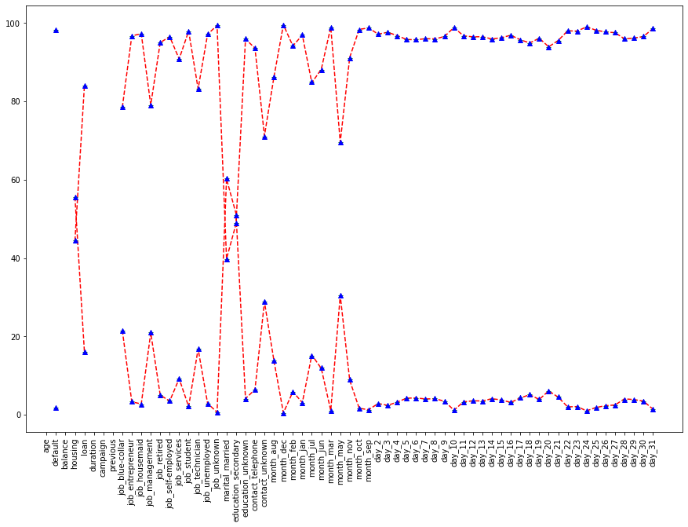

```python
plt.figure(figsize=(15,10))

plt.plot(bank_d_sum.columns, bank_d_sum.iloc[0,:], 'r--')
plt.plot(bank_d_sum.columns, bank_d_sum.iloc[1,:], 'r--')

plt.plot(bank_d_train_sum.columns,bank_d_train_sum.iloc[0,:], 'g+')
plt.plot(bank_d_train_sum.columns,bank_d_train_sum.iloc[1,:], 'g+')

plt.plot(bank_d_test_sum.columns,bank_d_train_sum.iloc[0,:], 'b^')
plt.plot(bank_d_test_sum.columns,bank_d_train_sum.iloc[1,:], 'b^')

plt.xticks(rotation=90)

plt.show()
```

The above plot is done only on categories [0, 1] since those values goes from 0%-100%. It excludes mean and std values where applicable. It has been done by selecting only rows 0 and 1 in all 3 dataframes (.iloc[0,:]).

## Deliverable 3 - Create the ensemble model

### 3.1 Build the ensemble models (Bagging and Boosting) and Decision Tree model (at least 4 models in total). Note the model performance by using different metrics. Use confusion matrix to evaluate class level metrics i.e. Precision/Recall

#### Models

4 methods have been used for training total of 8 models, each method for two models on two separate datasets generated in steps above.

Parametrisation of the models has been done based on expected/wanted outcome - in particular recall of models to be as high as possible (to gain as highest mark as possible - 5 marks for recall above 43%).

DecisionTree models were pruned with parameter max_depth equals to 6.

Random forest was trained with max_feature=10 (between two and sixtysomething) giving 10 possible fetures to be chosen from in a random fashion for each split, however, bootsrap was set to False (If False, the whole dataset is used to build each tree). It showed best results with regards to recall.

In AdaBoost and Bagging models base_estimator was used to enable class_weight parametrisation as well. This concept was lately abanodned (when tresholds have been introduced) base_estimator is simple decision tree with max_depth=2. Number of estimators (nr of trees) was left default. Even though bootstrap paramether might have been ommited for bagging models (since default value is True), it has been explicitly added to emphasize importance of it for bagging models.

In general, gini criterion was used in all models, to reduce computational time.

```python
#model
#decision tree
dt_model=DecisionTreeClassifier(criterion='gini', max_depth=6, random_state=7)
dt_model.fit(X_train, y_train)

dt_model_d=DecisionTreeClassifier(criterion='gini',max_depth=6, random_state=7)
dt_model_d.fit(X_train_d, y_train_d)
```

```
DecisionTreeClassifier(max_depth=6, random_state=7)
```

```python
#model
#random forest model
rf_model=RandomForestClassifier(criterion='gini',max_depth=6, max_features=10, random_state=7, bootstrap=False)
rf_model.fit(X_train, y_train)

rf_model_d=RandomForestClassifier(criterion='gini',max_depth=6, max_features=10, random_state=7, bootstrap=False)
rf_model_d.fit(X_train_d, y_train_d)
```

```
RandomForestClassifier(bootstrap=False, max_depth=6, max_features=10,
                       random_state=7)
```

```python
dt_model_for_ab_bg_model=DecisionTreeClassifier(criterion='gini', max_depth=2, random_state=7)
#dt_model_for_ab_model.fit(X_train, y_train)
```

```python
#model
#AdaBoost
ab_model=AdaBoostClassifier(algorithm='SAMME.R',base_estimator=dt_model_for_ab_bg_model, random_state=7)
ab_model.fit(X_train, y_train)

ab_model_d=AdaBoostClassifier(algorithm='SAMME.R',base_estimator=dt_model_for_ab_bg_model, random_state=7)
ab_model_d.fit(X_train_d, y_train_d)
```

```
AdaBoostClassifier(base_estimator=DecisionTreeClassifier(max_depth=2,
                                                         random_state=7),
                   random_state=7)
```

```python
#model
#Bagging
bg_model=BaggingClassifier(base_estimator=dt_model_for_ab_bg_model, max_samples= .7, bootstrap=True, random_state=7)
bg_model.fit(X_train, y_train)

bg_model_d=BaggingClassifier(base_estimator=dt_model_for_ab_bg_model, max_samples= .7, bootstrap=True, random_state=7)
bg_model_d.fit(X_train_d, y_train_d)
```

```
BaggingClassifier(base_estimator=DecisionTreeClassifier(max_depth=2,
                                                        random_state=7),
                  max_samples=0.7, random_state=7)
```

#### Predictions

Predictions are done based on best tresholds derived from the function best_treshold. This function searches for the optimal values of recall and precision based on f score. Recall-Precision curve has been chosen because of inbalanced data on target varibale. Since the class 0 of target variable is predominant we should not be interested in TN (higher TN is much easy to achieve compared to TP).

```python
#finding the best treshold for classification
def best_treshold(model, x_test_data, y_test_data):
    prob_prediction=model.predict_proba(x_test_data)[:,1]
    prec, recall, pr_tresholds=precision_recall_curve(y_test_data, prob_prediction)
    f_score_per_tresholds=2*prec*recall/(prec+recall)
    index_of_highes_f_score=list(f_score_per_tresholds).index(max(f_score_per_tresholds))
    plt.figure(figsize=(8,8))
    plt.title("Precission-Recall for different tresholds")
    plt.plot(recall[:-1], prec[:-1], "g", label="Precision-Recall")
    plt.plot(recall[index_of_highes_f_score], prec[index_of_highes_f_score], marker='o', color='black', label='Optimal')
    plt.xlabel("Recall")
    plt.ylabel('Precision')
    plt.legend()
    return (pr_tresholds[index_of_highes_f_score])
```

Prediction is calculated based on given best treshold (treshold calculated in function above). Basically the fucntion produces prediction array based on results of predict_proba fucntion of each model instance.

```python
def pred_treshold_based(treshold, x_test_data, model):
    prediction=[1 if x>=treshold else 0 for x in model.predict_proba(x_test_data)[:,1]]
    return (prediction)
```

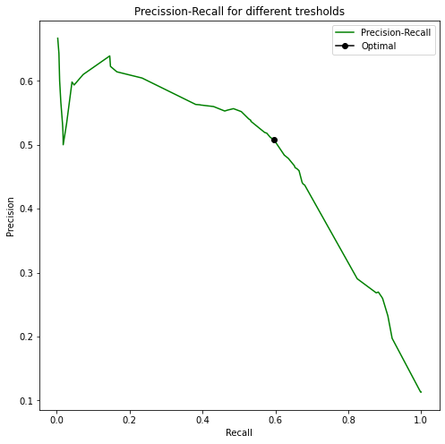

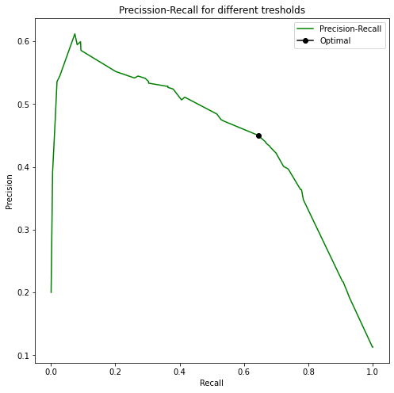

```python
#best tresholds for clasification
#decision tree tresholds
dt_model_best_treshold=best_treshold(dt_model, X_test, y_test)
dt_model_d_best_treshold=best_treshold(dt_model_d, X_test_d, y_test_d)
```

```python
#Prediction
#Decision tree
dt_model_y_predict=pred_treshold_based(dt_model_best_treshold, X_test, dt_model)
dt_model_y_predict_d=pred_treshold_based(dt_model_d_best_treshold, X_test_d, dt_model_d)
```

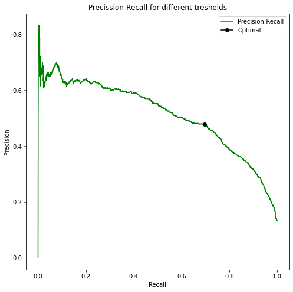

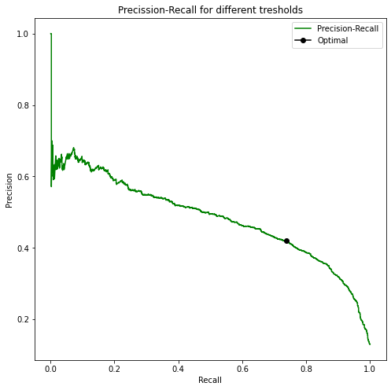

```python
#prediction
#random forest

#best_tresholds
rf_model_best_treshold=best_treshold(rf_model, X_test, y_test)
rf_model_d_best_treshold=best_treshold(rf_model_d, X_test_d, y_test_d)

#predictions
rf_model_y_predict=pred_treshold_based(rf_model_best_treshold, X_test, rf_model)
rf_model_y_predict_d=pred_treshold_based(rf_model_d_best_treshold, X_test_d, rf_model_d)
```

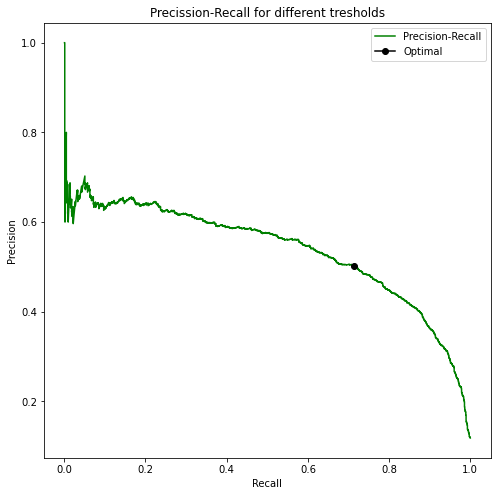

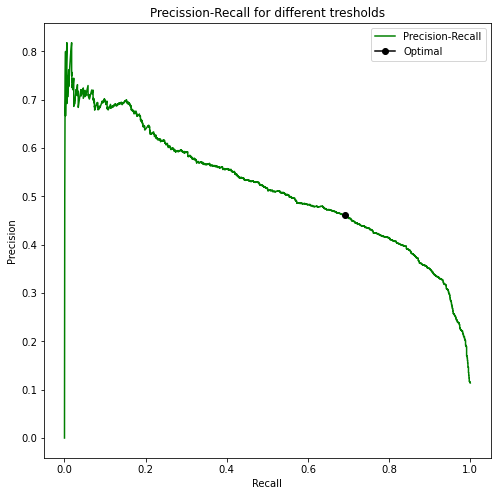

```python
#prediction
#AdaBoost
#best_tresholds
ab_model_best_treshold=best_treshold(ab_model, X_test, y_test)
ab_model_d_best_treshold=best_treshold(ab_model_d, X_test_d, y_test_d)

#predictions
ab_model_y_predict=pred_treshold_based(ab_model_best_treshold, X_test, ab_model)
ab_model_y_predict_d=pred_treshold_based(ab_model_d_best_treshold, X_test_d, ab_model_d)
```

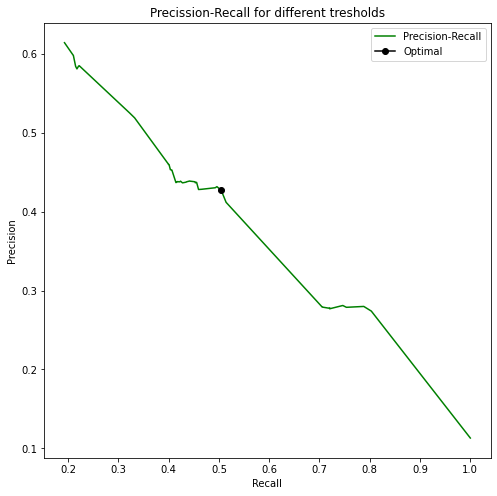

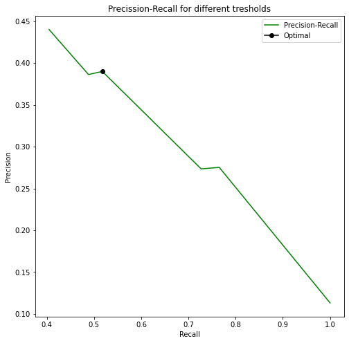

```python
#prediction
#Bagging
#best_tresholds
bg_model_best_treshold=best_treshold(bg_model, X_test, y_test)
bg_model_d_best_treshold=best_treshold(bg_model_d, X_test_d, y_test_d)

#predictions
bg_model_y_predict=pred_treshold_based(bg_model_best_treshold, X_test, bg_model)
bg_model_y_predict_d=pred_treshold_based(bg_model_d_best_treshold, X_test_d, bg_model_d)
```

#### Metrics

```python
#metrics
#decision tree
dt_model_score_train=dt_model.score(X_train, y_train)
dt_model_d_score_train=dt_model_d.score(X_train_d, y_train_d)

dt_model_score_test=dt_model.score(X_test, y_test)
dt_model_d_score_test=dt_model_d.score(X_test_d, y_test_d)

dt_model_recall=recall_score(y_test, dt_model_y_predict)
dt_model_d_recall=recall_score(y_test_d, dt_model_y_predict_d)

dt_model_precission=precision_score(y_test, dt_model_y_predict)
dt_model_d_precission=precision_score(y_test_d, dt_model_y_predict_d)

dt_model_f1_score=f1_score(y_test, dt_model_y_predict)
dt_model_d_f1_score=f1_score(y_test_d, dt_model_y_predict_d)

dt_model_roc_auc=roc_auc_score(y_test, dt_model_y_predict)
dt_model_d_roc_auc=roc_auc_score(y_test_d, dt_model_y_predict_d)


print('---------------Decision tree - gini inpurity --------------------')
print('')
print ('accuracy on train data of dt_model is', dt_model.score(X_train, y_train))
print ('accuracy on test data of dt_model is', dt_model.score(X_test, y_test))
print('')
print ('accuracy on train data of dt_model_d is', dt_model_d.score(X_train_d, y_train_d))
print ('accuracy on test data of dt_model_d is', dt_model_d.score(X_test_d, y_test_d))
print('')
print('recall for dt_model is', dt_model_recall)
print('recall for dt_model_d is', dt_model_d_recall)
print('')
print('precision for dt_model is', dt_model_precission)
print('precision for dt_model_d is', dt_model_d_precission)
print('')
print('f1 score for dt_model is', dt_model_d_f1_score)
print('f1 score for dt_model_d is', dt_model_d_f1_score)
print('')
print('roc auc score for dt_model is', dt_model_roc_auc)
print('roc auc score for dt_model_d is', dt_model_d_roc_auc)
print('')
print('---------------Decision tree - gini inpurity --------------------')
```

[output not shown]

```python
#metrics
#random forest

rf_model_score_train=rf_model.score(X_train, y_train)
rf_model_d_score_train=rf_model_d.score(X_train_d, y_train_d)


rf_model_score_test=rf_model.score(X_test, y_test)
rf_model_d_score_test=rf_model_d.score(X_test_d, y_test_d)

rf_model_recall=recall_score(y_test, rf_model_y_predict)
rf_model_d_recall=recall_score(y_test_d, rf_model_y_predict_d)

rf_model_precission=precision_score(y_test, rf_model_y_predict)
rf_model_d_precission=precision_score(y_test_d, rf_model_y_predict_d)

rf_model_f1_score=f1_score(y_test, rf_model_y_predict)
rf_model_d_f1_score=f1_score(y_test_d, rf_model_y_predict_d)

rf_model_roc_auc=roc_auc_score(y_test, rf_model_y_predict)
rf_model_d_roc_auc=roc_auc_score(y_test_d, rf_model_y_predict_d)


print('---------------Random forest --------------------')
print('')
print ('accuracy on train data of rf_model is', rf_model.score(X_train, y_train))
print ('accuracy on test data of rf_model is', rf_model.score(X_test, y_test))
print('')
print ('accuracy on train data of rf_model_d is', rf_model_d.score(X_train_d, y_train_d))
print ('accuracy on test data of rf_model_d is', rf_model_d.score(X_test_d, y_test_d))
print('')
print('recall for rf_model is', rf_model_recall)
print('recall for rf_model_d is', rf_model_d_recall)
print('')
print('precision for rf_model is', rf_model_precission)
print('precision for rf_model_d is', rf_model_d_precission)
print('')
print('f1 score for rf_model is', rf_model_d_f1_score)
print('f1 score for rf_model_d is', rf_model_d_f1_score)
print('')
print('roc auc score for rf_model is', rf_model_roc_auc)
print('roc auc score for rf_model_d is', rf_model_d_roc_auc)
print('')
print('---------------Random forest--------------------')
```

[output not shown]

```python
#metrics
#AdaBoost

ab_model_score_train=ab_model.score(X_train, y_train)
ab_model_d_score_train=ab_model_d.score(X_train_d, y_train_d)

ab_model_score_test=ab_model.score(X_test, y_test)
ab_model_d_score_test=ab_model_d.score(X_test_d, y_test_d)

ab_model_recall=recall_score(y_test, ab_model_y_predict)
ab_model_d_recall=recall_score(y_test_d, ab_model_y_predict_d)

ab_model_precission=precision_score(y_test, ab_model_y_predict)
ab_model_d_precission=precision_score(y_test_d, ab_model_y_predict_d)

ab_model_f1_score=f1_score(y_test, ab_model_y_predict)
ab_model_d_f1_score=f1_score(y_test_d, ab_model_y_predict_d)

ab_model_roc_auc=roc_auc_score(y_test, ab_model_y_predict)
ab_model_d_roc_auc=roc_auc_score(y_test_d, ab_model_y_predict_d)


print('---------------AdaBoost --------------------')
print('')
print ('accuracy on train data of ab_model is', ab_model.score(X_train, y_train))
print ('accuracy on test data of ab_model is', ab_model.score(X_test, y_test))
print('')
print ('accuracy on train data of ab_model_d is', ab_model_d.score(X_train_d, y_train_d))
print ('accuracy on test data of ab_model_d is', ab_model_d.score(X_test_d, y_test_d))
print('')
print('recall for ab_model is', ab_model_recall)
print('recall for ab_model_d is', ab_model_d_recall)
print('')
print('precision for ab_model is', ab_model_precission)
print('precision for ab_model_d is', ab_model_d_precission)
print('')
print('f1 score for ab_model is', ab_model_d_f1_score)
print('f1 score for ab_model_d is', ab_model_d_f1_score)
print('')
print('roc auc score for ab_model is', ab_model_roc_auc)
print('roc auc score for ab_model_d is', ab_model_d_roc_auc)
print('')
print('---------------AdaBoost--------------------')
```

[output not shown]

```python
#metrics
#bagging

bg_model_score_train=bg_model.score(X_train, y_train)
bg_model_d_score_train=bg_model_d.score(X_train_d, y_train_d)

bg_model_score_test=bg_model.score(X_test, y_test)
bg_model_d_score_test=bg_model_d.score(X_test_d, y_test_d)

bg_model_recall=recall_score(y_test, bg_model_y_predict)
bg_model_d_recall=recall_score(y_test_d, bg_model_y_predict_d)

bg_model_precission=precision_score(y_test, bg_model_y_predict)
bg_model_d_precission=precision_score(y_test_d, bg_model_y_predict_d)

bg_model_f1_score=f1_score(y_test, bg_model_y_predict)
bg_model_d_f1_score=f1_score(y_test_d, bg_model_y_predict_d)

bg_model_roc_auc=roc_auc_score(y_test, bg_model_y_predict)
bg_model_d_roc_auc=roc_auc_score(y_test_d, bg_model_y_predict_d)


print('---------------Bagging --------------------')
print('')
print ('accuracy on train data of bg_model is', bg_model.score(X_train, y_train))
print ('accuracy on test data of bg_model is', bg_model.score(X_test, y_test))
print('')
print ('accuracy on train data of bg_model_d is', bg_model_d.score(X_train_d, y_train_d))
print ('accuracy on test data of bg_model_d is', bg_model_d.score(X_test_d, y_test_d))
print('')
print('recall for bg_model is', bg_model_recall)
print('recall for bg_model_d is', bg_model_d_recall)
print('')
print('precision for bg_model is', bg_model_precission)
print('precision for bg_model_d is', bg_model_d_precission)
print('')
print('f1 score for bg_model is', bg_model_d_f1_score)
print('f1 score for bg_model_d is', bg_model_d_f1_score)
print('')
print('roc auc score for bg_model is', bg_model_roc_auc)
print('roc auc score for bg_model_d is', bg_model_d_roc_auc)
print('')
print('---------------Bagging --------------------')
```

[output not shown]

#### confusion matrix

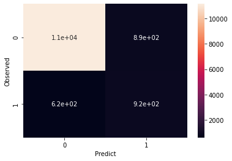

```python
#confusion matrix
#decision tree - dt_model
sns.heatmap(confusion_matrix(y_test, dt_model_y_predict), annot=True , xticklabels = [0,1] , yticklabels = [0,1])
plt.ylabel('Observed')
plt.xlabel('Predict')
plt.show()
```

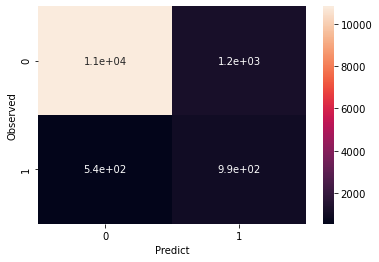

```python
#confusion matrix
#decision tree - dt_model_d
sns.heatmap(confusion_matrix(y_test_d, dt_model_y_predict_d), annot=True , xticklabels = [0,1] , yticklabels = [0,1])
plt.ylabel('Observed')
plt.xlabel('Predict')
plt.show()
```

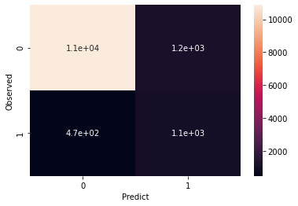

```python
#confusion matrix
#random forest - dt_model
sns.heatmap(confusion_matrix(y_test, rf_model_y_predict), annot=True , xticklabels = [0,1] , yticklabels = [0,1])
plt.ylabel('Observed')
plt.xlabel('Predict')
plt.show()
```

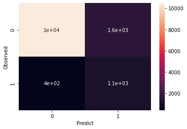

```python
#confusion matrix
#random forest - dt_model_d
sns.heatmap(confusion_matrix(y_test, rf_model_y_predict_d), annot=True , xticklabels = [0,1] , yticklabels = [0,1])
plt.ylabel('Observed')
plt.xlabel('Predict')
plt.show()
```

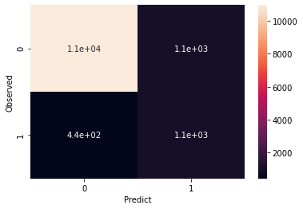

```python
#confusion matrix
#AdaBoost - dt_model
sns.heatmap(confusion_matrix(y_test, ab_model_y_predict), annot=True , xticklabels = [0,1] , yticklabels = [0,1])
plt.ylabel('Observed')
plt.xlabel('Predict')
plt.show()
```

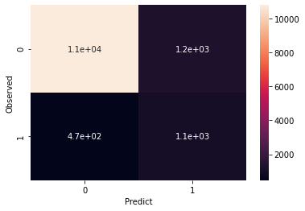

```python
#confusion matrix
#AdaBoost - dt_model_d
sns.heatmap(confusion_matrix(y_test, ab_model_y_predict_d), annot=True , xticklabels = [0,1] , yticklabels = [0,1])
plt.ylabel('Observed')
plt.xlabel('Predict')
plt.show()
```

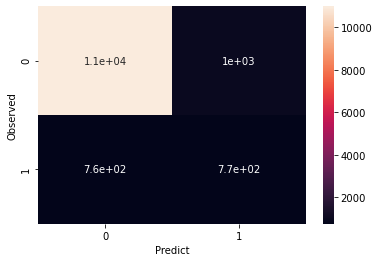

```python
#confusion matrix
#Bagging - dt_model
sns.heatmap(confusion_matrix(y_test, bg_model_y_predict), annot=True , xticklabels = [0,1] , yticklabels = [0,1])
plt.ylabel('Observed')
plt.xlabel('Predict')
plt.show()
```

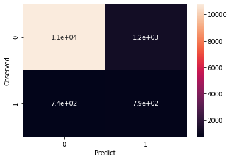

```python
#confusion matrix
#Bagging - dt_model_d
sns.heatmap(confusion_matrix(y_test, bg_model_y_predict_d), annot=True , xticklabels = [0,1] , yticklabels = [0,1])
plt.ylabel('Observed')
plt.xlabel('Predict')
plt.show()
```

### 3.2. Also reflect the training and testing score of all the models. Build a dataframe with model names as row index and all the metrics calculated as columns

```python
model_performance=pd.DataFrame({'Method':['DecisionTree','DecisionTree','RandomForest', 'RandomForest', 'AdaBoost', 'AdaBoost', 'Bagging', 'Bagging'],
              'ModelName':['dt_model', 'dt_model_d','rf_model','rf_model_d','ab_model','ab_model_d','bg_model', 'bg_model_d'],
              'TrainAccuracy':[dt_model_score_train, dt_model_d_score_train, rf_model_score_train, rf_model_d_score_train, ab_model_score_train, ab_model_d_score_train, bg_model_score_train, bg_model_d_score_train],
              'TestAccuracy':[dt_model_score_test, dt_model_d_score_test, rf_model_score_test, rf_model_d_score_test, ab_model_score_test, ab_model_d_score_test, bg_model_score_test, bg_model_d_score_test],
              'recall':[dt_model_recall, dt_model_d_recall, rf_model_recall, rf_model_d_recall, ab_model_recall, ab_model_d_recall, bg_model_recall, bg_model_d_recall],
              'precission':[dt_model_precission, dt_model_d_precission, rf_model_precission, rf_model_d_precission, ab_model_precission, ab_model_d_precission, bg_model_precission, bg_model_d_precission],
              'f1_score':[dt_model_f1_score, dt_model_d_f1_score, rf_model_f1_score, rf_model_d_f1_score, ab_model_f1_score,ab_model_d_f1_score, bg_model_f1_score, bg_model_d_f1_score],
              'roc_auc_score':[dt_model_roc_auc, dt_model_d_roc_auc,  rf_model_roc_auc, rf_model_d_roc_auc, ab_model_roc_auc, ab_model_d_roc_auc, bg_model_roc_auc, bg_model_d_roc_auc]},
             index=[0, 1, 2, 3, 4, 5, 6, 7])

model_performance
```

|  | Method | ModelName | TrainAccuracy | TestAccuracy | recall | precission | f1_score | roc_auc_score |
| --- | --- | --- | --- | --- | --- | --- | --- | --- |
| 0 | DecisionTree | dt_model | 0.899769 | 0.896859 | 0.596480 | 0.507488 | 0.548397 | 0.761332 |
| 1 | DecisionTree | dt_model_d | 0.894429 | 0.891477 | 0.645372 | 0.449796 | 0.530120 | 0.772353 |
| 2 | RandomForest | rf_model | 0.883212 | 0.887423 | 0.694915 | 0.478886 | 0.567021 | 0.799245 |
| 3 | RandomForest | rf_model_d | 0.883117 | 0.887275 | 0.739244 | 0.421092 | 0.536551 | 0.804826 |
| 4 | AdaBoost | ab_model | 0.900054 | 0.900693 | 0.713820 | 0.502524 | 0.589820 | 0.811856 |
| 5 | AdaBoost | ab_model_d | 0.893924 | 0.896196 | 0.691656 | 0.461104 | 0.553325 | 0.794290 |
| 6 | Bagging | bg_model | 0.887162 | 0.894721 | 0.504563 | 0.427152 | 0.462642 | 0.709139 |
| 7 | Bagging | bg_model_d | 0.881347 | 0.886907 | 0.517601 | 0.389980 | 0.444818 | 0.707180 |

### 3.3. Explain the confusion matrix related terms like recall, precision etc. Also, select the best metric to choose one of the models from above. Give your reason for the same.

Explanation of confusion matrix is as follows:

- predicted negative (0), observed negative (0) - true negative (TN) - model predicted that the customer did not subscribe term deposit and the customer realy did not subscribe term deposit; prediction was correct
- predicted negative (0), observed positive (1) - false negative (FN) - model predicted that customer did not subscribe term deposit while the customer actually did subscribe term deposit;prediction was incorrect
- predicted positive (1), observed positive (1) - true positive (TP) - model predicted that customer subscribed term deposit corectly; prediction was correct
- predicted positive (1), observed negative (0) - false positive (TP) - - model predicted that customer subscribed term deposit while in reallity he/she did not; prediction was incorect

Recall gives the information how many of true positives were captured among total (observed) positives. In this context - portion of customers captured by a model, who actually subscribed term deposit.

Precision on the other hand tells how many of those captured are relevant - it measures TP against total positive predictions.

### 3.4. Answer the following questions :

#### 3.4.1 What do you mean by recall and what information does it provide here?

Recall is caclulated from TP/(TP+FN). In this context it means a portion of subscribers who actually subscribed term deposit captured by a model. If used for a prediction it would mean that subscriber was offered a term deposit and he/she took the offer. The offer was not wasted.

#### 3.4.2. Suggest some changes for the organization so that they can increase the number of customers who take term deposit

The easiest way for the orgnaisation is to increase base of the cusotmers to whom the offer of term deposit will be provided. It would easily increase number of term deposits, however, caution is advised if campaign requires financial support, since it could easily reudce effectivness of such campaign - it might increase FP as well.

#### 3.4.3. How much influence does the previous campaign and mode of interaction have on financial performance

To check the impact of last campaign, importance of the features is checked. Then the conclusion might be derived based on features related to previous camapign like duration of last contact, number of previous contacts, mean of contact etc.

- dt_model

```python
features = X_train.columns

feat_importance=dt_model.tree_.compute_feature_importances(normalize=False)

feat_imp_dict = dict(zip(features, dt_model.feature_importances_))
feat_imp = pd.DataFrame.from_dict(feat_imp_dict, orient='index')
feat_imp.sort_values(by=0, ascending=False)
```

|  | 0 |
| --- | --- |
| duration | 0.582917 |
| housing | 0.103994 |
| previous | 0.098430 |
| age | 0.042903 |
| contact_unknown | 0.040411 |
| ... | ... |
| job_blue-collar | 0.000000 |
| day_2 | 0.000000 |
| job_services | 0.000000 |
| day_7 | 0.000000 |
| day_31 | 0.000000 |

65 rows × 1 columns

```python
feat_imp[feat_imp.index=='contact_telephone']
```

|  | 0 |
| --- | --- |
| contact_telephone | 0.0 |

```python
feat_imp[feat_imp.index=='contact_unknown']
```

|  | 0 |
| --- | --- |
| contact_unknown | 0.040411 |

- dt_model_d

```python
features_d = X_train_d.columns

feat_importance_d=dt_model_d.tree_.compute_feature_importances(normalize=False)

feat_imp_dict_d = dict(zip(features_d, dt_model_d.feature_importances_))
feat_imp_d = pd.DataFrame.from_dict(feat_imp_dict_d, orient='index')
feat_imp_d.sort_values(by=0, ascending=False)
```

|  | 0 |
| --- | --- |
| duration_d | 0.555153 |
| housing | 0.108254 |
| previous | 0.102351 |
| age | 0.047465 |
| month_mar | 0.037058 |
| ... | ... |
| day_9 | 0.000000 |
| day_10 | 0.000000 |
| job_unemployed | 0.000000 |
| day_12 | 0.000000 |
| day_31 | 0.000000 |

64 rows × 1 columns

```python
feat_imp_d[feat_imp_d.index=='contact_telephone']
```

|  | 0 |
| --- | --- |
| contact_telephone | 0.0 |

```python
feat_imp_d[feat_imp_d.index=='contact_unknown']
```

|  | 0 |
| --- | --- |
| contact_unknown | 0.029236 |

#### 3.4.4. Which features should be more/less focused by the bank to get better results and why?

Communication to the customer about term deposit offers should be more focused on, since parameters with regards to previous camapign were more influential in models.

```python
feat_imp[feat_imp[0]==0]
```

|  | 0 |
| --- | --- |
| default | 0.0 |
| job_blue-collar | 0.0 |
| job_entrepreneur | 0.0 |
| job_housemaid | 0.0 |
| job_management | 0.0 |
| job_retired | 0.0 |
| job_self-employed | 0.0 |
| job_services | 0.0 |
| job_student | 0.0 |
| job_technician | 0.0 |
| job_unemployed | 0.0 |
| job_unknown | 0.0 |
| education_secondary | 0.0 |
| contact_telephone | 0.0 |
| month_dec | 0.0 |
| month_feb | 0.0 |
| month_jan | 0.0 |
| month_jul | 0.0 |
| day_2 | 0.0 |
| day_6 | 0.0 |
| day_7 | 0.0 |
| day_8 | 0.0 |
| day_9 | 0.0 |
| day_12 | 0.0 |
| day_14 | 0.0 |
| day_16 | 0.0 |
| day_17 | 0.0 |
| day_18 | 0.0 |
| day_19 | 0.0 |
| day_20 | 0.0 |
| day_21 | 0.0 |
| day_23 | 0.0 |
| day_24 | 0.0 |
| day_25 | 0.0 |
| day_26 | 0.0 |
| day_27 | 0.0 |
| day_28 | 0.0 |
| day_29 | 0.0 |
| day_31 | 0.0 |

```python
feat_imp_d[feat_imp_d[0]==0]
```

|  | 0 |
| --- | --- |
| default | 0.0 |
| job_housemaid | 0.0 |
| job_management | 0.0 |
| job_self-employed | 0.0 |
| job_student | 0.0 |
| job_technician | 0.0 |
| job_unemployed | 0.0 |
| job_unknown | 0.0 |
| education_secondary | 0.0 |
| education_unknown | 0.0 |
| contact_telephone | 0.0 |
| month_dec | 0.0 |
| month_jul | 0.0 |
| day_2 | 0.0 |
| day_4 | 0.0 |
| day_5 | 0.0 |
| day_6 | 0.0 |
| day_8 | 0.0 |
| day_9 | 0.0 |
| day_10 | 0.0 |
| day_12 | 0.0 |
| day_14 | 0.0 |
| day_17 | 0.0 |
| day_18 | 0.0 |
| day_19 | 0.0 |
| day_21 | 0.0 |
| day_22 | 0.0 |
| day_23 | 0.0 |
| day_24 | 0.0 |
| day_25 | 0.0 |
| day_26 | 0.0 |
| day_27 | 0.0 |
| day_28 | 0.0 |
| day_29 | 0.0 |
| day_31 | 0.0 |